# The Financial Press and Stock Markets in Times of Crisis

### Whitepaper Analysis - 27/08/15 - Marcus Williamson

Please find link to follow up piece [here](https://github.com/mw572/financial-markets/blob/master/Whitepaper%20Research/The%20financial%20press%20and%20stock%20markets%20in%20times%20of%20crisis/Whitepaper%20Experimentation.md)

#### Format:

**1. Summary of paper (short)**

**3. Criticisms & queries**

**4. Condensed paper with focus on insights & charts**

#### 1. Summary of paper:

- This paper examines the relationship between negative news and correlation & volatility
- This is specifically examined with focus on:
  - WSJ - DJ Ind. Avg. (US)
  - FT - FTSE 100 (UK)
  - MIB - II Sole24ore (IT)
- Analysis was completed roughly over the Subprime crisis (Sept 08 - Sept 09)
- Bad news index was derived from Emphasis & Tone:
  - The emphasis was measured by counting the number of banner columns reporting an economic news compared with the total number of potentially available columns.
  - The tone was measured by counting the ratio of negative words over the total words used in the headline text
- “One lag” = 1 Trading day

#### 3. Criticism & queries

- Lag is defined in original equations for k = 1,..,p however “for simplicity” k=1 is selected without any consideration of any higher lag. Although this is a logical conclusion it would not have been time consuming or difficult to test an information criterion to confirm this is a logical choice. If this was done it should have been mentioned in the paper in my opinion
- Loose conclusions on predictability:
  - **“Generally speaking, we could not predict market volatility only by looking at financial press bad news.”**
  - **“In particular, our results showed that the Wall Street Journal strongly predicted market correlation and volatility.”**
- Its logical that volatility is not only predicted by financial bad press (although it does contribute to), however its later phrased that WSJ **strongly predicted market … volatility**, this is misleading. Although it does statistically influence volatility to a significant level (it would appear) I struggle with the concept of it predicting the overall volatility, as per the first statement.
- Why FT was chosen with FTSE and WSJ with Dow Jones?
  - Was there any initial testing, was this drawn out as logical best fit?
  - I believe there should have been some initial screening to look at best coverage such as % of focus on country in question by news paper, and mentions of events/companies/entities of target country
  - This is one of the most core aspects to this study, and it is assumed logical and correct.

#### 4. Condensed Paper

- This paper looks at the relationship between negative news on stock markets and times of global crisis, such as 2008. We analyse one-year front-page banner headlines of three financial newspapers, the Wall Street Journal, financial times, and sole24ore to examine the influence of bad news both on stock market volatility and dynamic correlation. Results showed that the press and the markets influence each other in generating market volatility and in particular, that the Wall Street Journal had a crucial effect both on the volatility and correlation between the US and foreign markets. We also found significant differences between the newspapers in their interpretation of the crisis, with the financial Times being significantly pessimistic evening phases of low market volatility. Our results confirm the reflective nature of stock markets. When the situation is and says and unpredictable, market behaviour may even reflect qualitative, big picture, and subjective information such as streamers in newspapers, whose economic and informative valuable is questionable.
- The financial press has significantly influence the stock market, often amplifying a cognitive bias and her behaviour of investors. This behaviour may depend on the strong sensitivity messes towards bad news. Recent studies have shown that market responses to good and bad news is asymmetric.
- Indeed, investors are more sensitive to negative news, especially when the market is dominated by uncertainty and unpredictability, and this is an important source of market volatility, It was found that stock prices overreacted to bad news even good times and under reacted to good news in bad times.
- Data has been analysed from 1 September 2008 to 1 September 2009 when the recent financial crisis exploded globally. We created an index of bad news per newspaper on a daily basis and study the relationship between this index and the closing values of three stock market indexes such as the Dow Jones, FTSE, MIB. We considered the stock markets as they were more domestically affected by these newspapers.
- This report rather than considering specific market information as reported in specialise columns, we looked at the impact of general information provided by front-page headlines of the financial press. Indeed, front-page headlines are crucial in summarising the meaning, tone and importance of the news but I’m not expected to contain true, precise and detailed information about economic facts, unlike specialise columns.
- This is because:
  - Headline information is too succinct
  - FrontPage messages heavily reflect specific information strategies of newspapers, which are mainly concerned with the impressing and attracting the reader
- Interest was not restricted to strictly speaking financial news but economic information was also considered. Specific stocks were not focused on but rather general information which reflects more interpretation and objective details was the focus.
- This is the first work extends analysis of the impact of financial press from market market volatility to mkt. correlation. Combining volatility and correlation is key to:
  - Understanding of bad news had an effect on the growing interdependence of markets, which is presumably correlated with crisis periods
  - Looking at the impact of bad news not only from the point of view of risk but also from that of the risk diversification. We estimated the volatility and correlation dynamics using generalisable to regressive conditional heteroscedasticity GARCH models.
  - Secondly we estimated the dynamic relationships between market volatility/correlation and bad news by using vector autoregressive models (VAR) .
  - We also performed a Granger causality test to verify whether bad news time series have predicted value for market volatility/correlation.

**Background and hypotheses**

Many studies in finance have shown the stock market prices incorporate financial press information, or this may be expected in case of quantitive information on important economic statistics, such as those regularly release by important institution agencies, it is less likely to find a positive impact of quality of information, such as journalists opinions or reports of market rumours, which is subjective. Nevertheless interpret evidence is growing in this area. For instance, examine dartboard, a monthly column of the Wall Street Journal reporting analyst recommendations from 1988 to 1990. Results show that the two days following the publication, average positive abnormal returns of 4% of the stock recommending partially reversed only within 25 trading days. Similarly, examine the rest of the market are popular con of the Wall Street Journal, from 1984 to 1999. It is worth noting that, unlike dartboard, which asked market analyst opinions, this column is closer to entertainment information. The author found a even qualitative information such as the fraction of negative words in this column, was incorporated in aggregate market valuations. More specifically results showed that the high level of pessimism to predict high market trading volumes. More recently, examined 30 years of abreast of the market and showed that even specific columnists can have influence on stock market behaviour.

This analysis was expanded by addressing the impact of negative words in all Wall Street Journal and Dow Jones news service stories about the individual S&P500 from 1982 - 2004. Results showed that negative words in the financial press forecasting low thermal earnings and that stock market prices Inc the information embedded in negative words only with a slight delay. This would confirm that bad news is assimilated faster than the ones in market behaviour. Other studies show that this effect was even truth on conventional, and specialise media, his information should be less relevant for investors. For example, Messages posted on Yahoo Finance and raging Bull about 45 companies in the Dow Jones industrial average and the Dow Jones into index, by measuring bullishness, It was found that stop messages help to predict market volatility both on a daily basis and also within the same training day. More specifically, they found a higher message postings predicted negative subsequent returns they also found a disagreement between the posted messages was associated with increased trading volumes. More recently it was found that twitter mood predicted more than 80% of daily volatility of closing values of the Dow Jones industrial average. This would confirm Nofsingers’s arguments that social mood may cause an increase of decisions bias by optimism and pessimism that could considerably influence aggregate investment and business activity, even reflecting future economic activity. The idea that the markets are influenced by reflexivity mechanisms has been explained by recent sociology investigations, which is mostly examine training activities in specific organisational context. Unfortunately, the studies underestimate the importance of understanding how context specific empirical cases could result in aggregate constant market data. The aim of this white paper what’s to fill this gap by formulating empirically testing certain hypotheses under the influence of press information on stock market behaviour comparatively, so as to consider possible institutional diversity in a relationship between financial press and markets.

**Hypotheses intro**

Is been previously shown that investors, even those following long-term strategies, I’m more influenced by negative news as they reduce the difficulty in predicting future outcomes but overestimated the impact of current information. This was also found in experimental and economic psychology. Our hypothesis is that the importance of these psychological factors could dramatically increase during financial turmoil as investors tend to disqualify the reliability of prices and even the well functioning of markets and the more sensitive to other sources of information, including newspaper headlines. Indeed, the fact the information subjective to profit maximisation by newspapers should make investors cautious of the sources. Furthermore, unlike efficient market hypothesis, in experimental research has shown that, in uncertainty, investors tend to overestimate the informational gap and are sensitive to any additional information, including subjective one.

- H1:
  - Bad news published by the financial newspapers could negatively influence the daily volatility of financial markets during this period. Secondly, although most financial crisis had had an International impact in the past, the 2008 2009 crisis was truly global as financial markets and are extremely interdependent. Numerous previous studies show that market interdependence tends to be highly correlated with periods of volatility. For instance, it’s been suggested that in periods of crisis and high market volatility, covariance could even include marketing do not have much in common. It was suggested that this trend has intensified especially recently with increasing globalisation of investment strategies
- H2:
  - In periods of turmoil, bad news could even influence market correlation and has an impact on global investment strategies. Coherently, we expected that in this period of the interplay financial markets and the press could determine a cascade of pessimism that co-influence both information and market behaviour.

**Data:**

**The bad news index:**

- Our dataset includes one year of front page banner headlines of three financial newspapers, namely:
  - Wall Street Journal
  - Financial Times
  - Il Sole24ore, on a daily base.
- For technical constraints, i.e., the unavailability of fully accessible electronic editions or lack of front page news included in electronic versions, we collected data manually on printed versions of the newspapers. Budget, time and linguistic constraints did not permit us to consider other national newspapers or cover longer time periods. The dataset and a text file, including a full description of the variables, are available as supplementary information.
- We analysed any front page banner headline from 1st September 2008 to 1st September 2009 which conveyed news on the crisis (not only those expressly related to financial markets) **by measuring the emphasis and the tone of the message**. The emphasis was measured by counting the number of banner columns reporting an economic news compared with the total number of potentially available columns, according to standard newspaper layout. We assumed that the higher the percentage of columns assigned to the banner headline, the stronger the emphasis of the message was. The tone was measured by counting the ratio of negative words over the total words used in the headline text (all included, also verbs and conjunctions), such as ‘‘recession’’, ‘‘fear’’ and so on. We assumed that the higher was the number of negative words in the text, the stronger the pessimism of the message was. For the sake of simplicity, we did not distinguish the degree of pessimism by raking the words used.
- Our bad news index was based on three types of information:
  - We considered the number of negative banner headlines on the crisis, Lk,t
  - The number of columns, Ck,t
  - Where news were reported, and the number of negative words reported in the text, Nk,t , at time t for each journal k~F ,W ,S, where F stands for Financial Times, W for Wall Street Journal, and S for IlSole24ore.
  - It is worth noting that the time index t refers to open-trading days, so time t~1, . . . 250 days. The information from the press during a non-trading day is reported together with the information of the first subsequent open-trading day. The index was built as follows.

**Descriptive statistics**

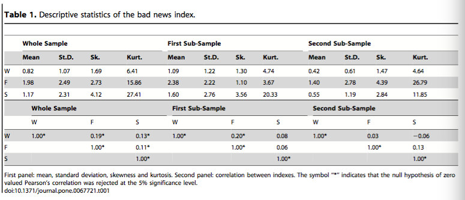

If we considered bad news dynamics, our one-year sample could be approximately divided into two subsamples, i.e., an initial period characterised by higher concentration of bad news, and the second one after Spring 2009, where bad news were generally less frequent. By comparing the three newspapers, it is evident that Wall Street Journal was more cautious and the financial Times published bad news more frequently, also for the second subsample.

Table 1 shows mean, standard deviation, skewness and kurtosis of the bad news index the newspaper. Looking at the mean value of the bad index, it is worth noting that the financial Times is more pessimistic than the other newspapers. On the other hand, if we consider the deviation from the mean (Skewness) an extreme values (Kurtosis) , sole24Orc, showed high excess pessimism. The Wall Street Journal was more cautious ready entire sample, i.e., it showed both lower means and volatility. We distinguished to subsamples, the first from 1 September 2008 to 30 March 2009, where the market volatility was considerably higher, the second from 31 March 2009 to 1 September 2009, with less volatility.

Our database also included the names in the amount of journalist to alter any front page leading article on the crisis. We calculated a Gini index that measure the concentration of articles per journalist. Not only did the financial Times concentrate more articles with fewer journalists (WSJ index 0.61, while FT took 0.66), It did so especially in low market volatility period (WSJ index for the second subsample took 0.68, while FT took 0.77). This meant that the stronger critical stance of the financial times in times of lower market volatility was due to fewer critical journalists.

[figure not shown]

The next step was to calculate the correlation between newspapers, results show that newspaper pessimism was significantly positively correlated. The more positive correlations were between the Wall Street Journal in the financial Times, and between the Wall Street Journal and Il Sole24Ore. If we consider the difference between periods of high low market volatility, it is worth noting that the high correlations were in higher volatility periods between the Wall Street Journal of the financial Times, whereas correlations were not significant or negative in periods of low volatility. This meant that in periods of higher market volatility, differences between Wall Street Journal and financial Times drastically diminished. Indeed, in this period, these two leading newspapers basically conformed both in terms of timing and intensity of pessimism. On the other hand, significant differences persisted for other periods when market volatility was less pronounced.

**Market volatility and correlation**

Let Xi,t indicate the log-return at time t for FTSE (i=UK), DowJones (i=US) and MIB (i=IT), the three stock market financial indexes to which the three newspapers refer more frequently. Let us calculate their volatility and correlation dynamics by means of a generalized autoregressive conditional heteroskedasticity (GARCH) model with dynamic conditional correlation. For the sake of simplicity, we followed a non-parametric approach as follows:

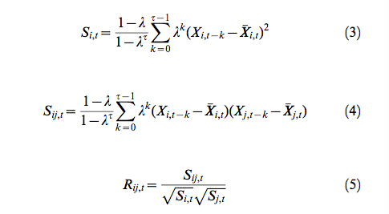

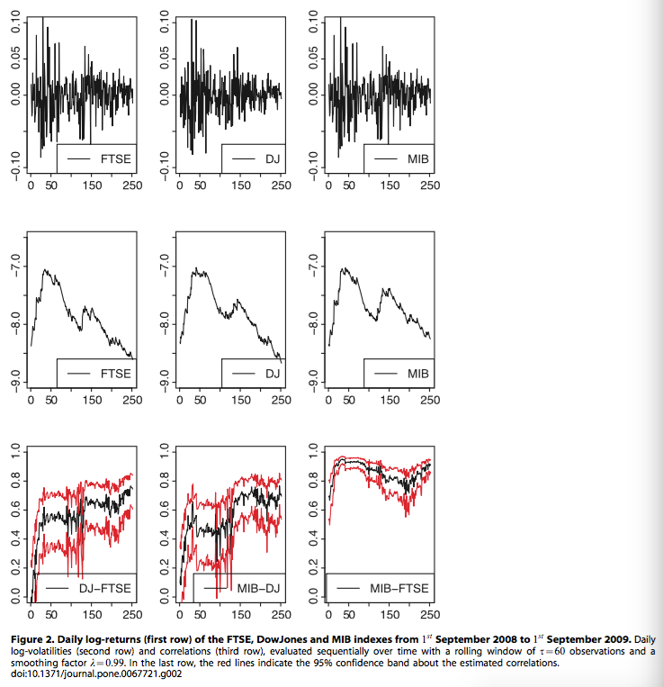

The figure above shows the results of on nonparametric estimation procedure. The first row shows the log returns of the FTSE, Dow Jones and MIB market indices daily basis for closing values.

These results confirm certain previous empirical findings on the higher correlation between markets during a financial crisis, especially in periods of higher volatility of the U.S. stock markets. Secondly, they would confirm recent findings on the increasing interdependence of European stock markets.

**Analysis**

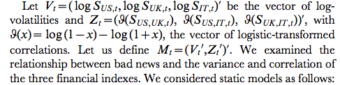

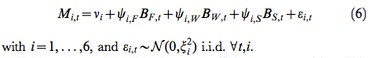

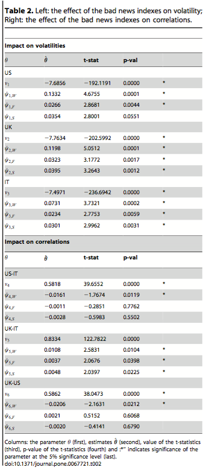

**Statistical Causal Relations**

VOLATILITY

A joint test on the statistical causal relationships of volatility and pessimism was based on the following VAR model of dimension 6 and order p:

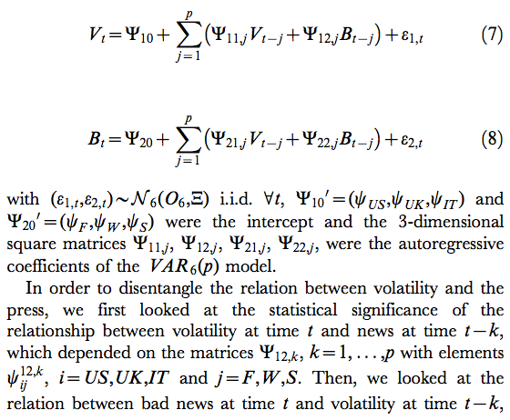

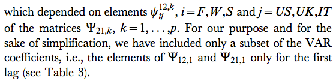

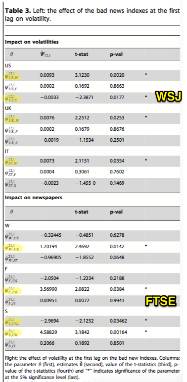

Results showed that: 1. **Wall Street Journal** bad news (lagged by one period) **significantly increased the volatility of the three market indexes in the subsequent period** (see the left panel in Tab. 3). This is further confirmation of the leadership of this newspaper and its worldwide impact. 1. The bad news of other newspapers did not have any significant impact on market volatility, with the exception of the lagged relation between **Il Sole24Ore** bad news and the volatility of the **U.S. market**. 1. Considering the effect of market volatility on bad news, it is worth noting that the **FTSE volatility** had a significant and positive impact on the bad news **of each newspaper** (see the right panel in Tab. 3). This would confirm the recent worldwide importance of the London stock market. 1. Finally, it is worth noting that the **volatility of the Dow Jones** index had a significant and negative impact on **Il Sole24ore** bad news.

We tested the hypothesis that volatility did not jointly statistically cause, in a Granger sense, the bad-news indexes. To look at the causal relationship between each market-specific volatility and the three newspapers, we also tested separately the hypothesis that neither each one of the three bad-news indexes, nor all three indexes jointly considered statistically caused, in a Granger sense, the market-specific volatility. To look at the relationship between each newspaper and the three markets, we did the same for newspaper bad news.

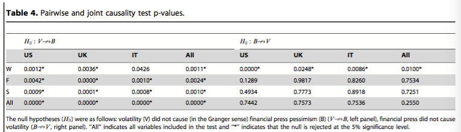

Tab. 4 shows the results of these joint and pairwise tests. First, the p-value of the joint test in the last column and last row, in the left panel, indicates that newspaper bad news was fully caused by market turmoil. Therefore, stock market behaviour was the essential source of bad news and newspapers did not have unrealistically pessimistic stances. Secondly, if we look at the p- values of almost all the pairwise causality tests (see the left panel), this statistical causality direction from markets to newspapers was true for all log-volatility and bad news indexes. On the other hand, if we look at the p-values in the last column, last row in the right panel, we should conclude that, in general, the financial press did not determine market volatility. More specifically, results showed that Wall Street Journal bad news alone had a strong statistical, causal impact on market volatility (see the first row in the right panel). **Generally speaking, we could not predict market volatility only by looking at financial press bad news**.

CORRELATIONS

The VAR model of order q for bad-news indexes and correlations was as follows:

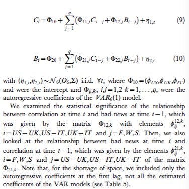

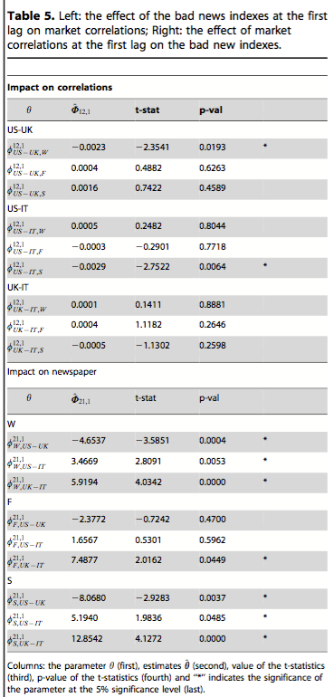

Our results (see Table 5, left column) showed that: 1. **Wall Street Journal** bad news (one lag) had a **negative impact on the correlation between U.S. and UK stock markets**. Indeed, bad news in the Wall Street Journal reduced the co-movement of these markets. This could be explained in terms of outflow of capital from the U.S. stock market and inflow into the UK market. 1. On the other hand, **Financial Times** bad news (one lag) had **no significant impact on market correlations**. 1. **Il Sole24ore** bad news **decreased the correlation between the U.S. and Italian stock markets**. The same explanation is a possible reason.

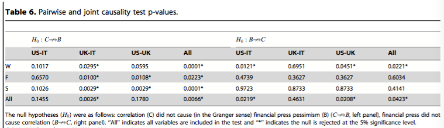

Therefore, any bad news in the Wall Street Journal predicted correlation between the U.S. and the other stock markets. Following certain peculiarities of Wall Street Journal as discussed in Sect 3 (see Table 2), such as its worldwide recognized leadership and strong focus on domestic affairs, **this meant that investors considered any bad news published in this influential newspaper as a good prediction of market behaviour and promptly reacted by drastically modifying their global investment strategies**.

Our findings confirm the sociological argument of the reflexive nature of stock markets. We found that media and markets are so systematically related to extend this reflexivity also to qualitative, subjective, broad picture information sources, whose true economic value should be seriously questioned from a mainstream, ‘efficient market hypothesis’ approach. On the other hand, especially if we look at the stronger influence of Wall Street Journal, we can argue against the common sense belief that newspapers would have over-exaggerated the dramatic events of 2008/2009 by imposing a critical stance which contributed to a cascade and contagion of pessimism.

ROBUSTNESS AND SENSITIVITY ANALYSIS

In order to corroborate our findings better, we performed further statistical tests to verify if certain specificities of market behaviour, such as downturn or upturn phases, could have had a consequence on the predictive power of the bad news index on market volatility and correlation. To do so, we re-estimated the VAR models for volatility and correlation described in the previous section by using alternatively the lowest and the highest returns of each trading day in the calculation of volatility and correlation. This was to estimate the impact of bad news on more point-to-point market behaviour, where it is less likely that stock markets fully reverberated all potential effects of a bad news. Table 7 shows that Wall Street Journal bad news had a significant impact on extreme returns (see High and Low columns), so confirming previous findings: 1. Furthermore, results showed that the **Wall Street Journal not only had a significant effect on the U.S.-UK market correlation, but also on other correlations**. 1. On the other hand, the effect of market correlation on the **Wall Street Journal bad news was more significant for closing returns than for low and high returns**. This meant that **the higher the correlation between markets, especially between the U.S. and UK markets, the lower the bad news index of the Wall Street Journal was**. 1. The situation with the **Financial Times was different**. In this case, the effect of **correlation for low and high returns were statistically stronger than that of closing returns**. Il Sole24ore showed weak correlation effects in these downturn and upturn cases. 1.It is important to note that the **FTSE-MIB correlation had a strong effect on the Il Sole24ore bad news independent** of the type of market phases.

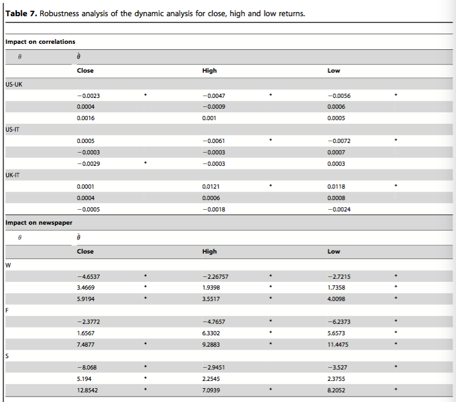

We then examined the robustness of the results on the choice of the smoothing factor in the estimation of volatility and correlation. Lower values of corresponded to higher weights for the most recent observations in the window considered. This leads to volatility and correlation that were more sensitive to large variations in returns. Thus we verified whether these results survived to the inclusion of a higher level of noise in the estimation of variance and correlation. Table 8 shows that Wall Street Journal bad news index was significant for the DJ-FTSE correlation as in previous analysis, but that it was also significant for DJ-MIB correlation. It is worth noting that, in this case, the Financial Times became statistically significant for FTSE-MIB correlation.

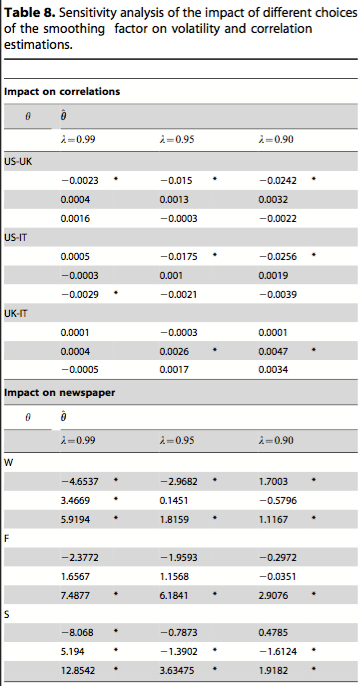

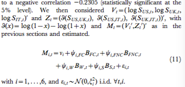

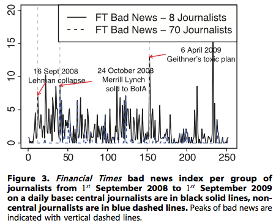

DISCUSSION

In an interesting personal account on 2008/2009 events, Peter S. Goodman, now executive business editor of the Huffington Post, past national correspondent for the New Work Times, reported that:

> “Inside our newsroom in midtown Manhattan, we understood that were were not merely passive chroniclers of external events. The sportswriter can describe what is happening on the field from a dispassionate distance, without imagining that the words he types may somehow influence the events he is witnessing. Not so for those of us writing about the financial crisis: were were effectively on the field while the game was still under way. Investors and markets and ordinary people would move their money in reaction to what we and other major media were reporting, and this would in turn affect the policy climate, the perception of need for emergency measures, the politics of the debate over those measures, and the public mood, which then reverberated back on everything else.”

This personal view testifies to the reflexive nature of markets and the limitation of the mantra of the market efficiency hypothesis. Our findings showed that the idea of reflexivity may contemplate that, in periods of crisis and market unpredictability, even distant information, subjective opinion and economically irrelevant facts may influence market behaviour. Probably, this is due to the fact that today economic, information, technological, and social systems are more strongly and globally coupled than in the past. This means that investors cannot easily predict future outcomes and tend to extend their social reflexivity towards non- operational, non strictly market related events and processes, e.g., by considering that general events, board picture information and the opinion of influential newspapers might have an informative value for markets.

This findings has interesting implications for the financial press. Indeed, following Goodman’s argument, a competent, reliable and responsible information is crucial for markets to work well, especially in periods of financial turmoil. This means that it is important to carry out more serious investigation on the ethics and responsibility of the financial press to establish new standards of conduct and better incentives and sanctions to support reliable information. Secondly, our findings showed that the increasing globalization of financial markets and their correlation in times of crisis require the press to truly cover the international dimension of business and be less parochial. This challenges the quality of the press coverage of global market dynamics and indicates the need for improving the public understanding of the intricate mechanisms of stock markets.

Finally, certain limitations of our work should be considered. First, we did not study the influence of the financial press on stock markets but only that of bad news. This gave us a narrow view of the link between the press and markets. Secondly, we studied the relationship of the financial press and stock markets in an ‘‘abnormal’’ market phase, where market behaviour was strongly subjected to irrational expectation and social mood. We intentionally selected this period as we expected that, in these situations, the pessimism of the financial press and its cross-sectoral dynamics could help us to understand the crisis better. While our results do not contribute to a general theory of the link of press and markets, they can provide important insights to understand the ‘social construction’ of pessimism between press and markets.

Moreover, it is also important to note that press pessimism and market behaviour could also be conditioned by other media, such as the new social media and the Internet. Comparing behaviour and impact of various media would be essential to provide a more precise analysis of the 2008/2009 crisis and draw more general remarks of the complex ways through which market sentiment tends to form today. The same holds for the idea of including other newspapers and markets, which may help us to have a more complete picture of the recent crisis and its global dimension.